# exploration_fordgobike

## Bike Sharing Analysis with Ford GoBike Data

### Introduction

This data set includes information about individual rides made in a bike-sharing system covering the greater San Francisco Bay, California. Bay Area Bike Share is a company that provides on-demand bike rentals for customers. A full story of creating and developing of the company is available on [wikipedia](https://en.wikipedia.org/wiki/Bay_Wheels#/media/File:Bay_Area_Bike_Share_launch_in_San_Jose_CA.jpg)

### Data

Data broadly described specifications regarding [trips from 2017 up to December 2020 can be found there](https://s3.amazonaws.com/baywheels-data/index.html). The data is spread in 18 csv files, most of them zipped, but one unzipped having a size of 118 MB. I downloaded the files and saved them in the folder 'data' (and zipped the unzipped file then sizing 18MB in order to comply with GitHubs file size limits).

```python
# import all needed libraries
import pandas as pd
import os
import numpy as np
import matplotlib.pyplot as plt
import seaborn as sb
import seaborn as sns
import datetime
from timeit import default_timer as timer

%matplotlib inline
```

```python
# ## My OS is Windows 10, that's why I used this format of path instead of /
# files_list = os.listdir(".\\baywheels-data")
# dataframes = []

# for file_name in files_list:
#     if (file_name.endswith(".zip")):
#         dataframes.append(
#             pd.read_csv(
#                 "baywheels-data/" + file_name,
#                 compression='zip',
#                 index_col=None,
#                 header=0,
#                 sep=',',
#                 quotechar='"',
#                 low_memory=False)
#         )

# joined_dataframe = pd.concat(
#     dataframes,
#     axis=0,
#     ignore_index=True,
#     sort=False
# )
```

```python
# joined_dataframe.to_csv('ford_go_bike.csv', index=False, encoding = 'utf-8')
```

```python
df = pd.read_csv('ford_go_bike.csv', low_memory=False)
```

```python
df.head()
```

|  | duration_sec | start_time | end_time | start_station_id | start_station_name | start_station_latitude | start_station_longitude | end_station_id | end_station_name | end_station_latitude | ... | ride_id | rideable_type | started_at | ended_at | start_lat | start_lng | end_lat | end_lng | member_casual | is_equity |
| --- | --- | --- | --- | --- | --- | --- | --- | --- | --- | --- | --- | --- | --- | --- | --- | --- | --- | --- | --- | --- | --- |
| 0 | 80110.0 | 2017-12-31 16:57:39.6540 | 2018-01-01 15:12:50.2450 | 74 | Laguna St at Hayes St | 37.776435 | -122.426244 | 43 | San Francisco Public Library (Grove St at Hyde... | 37.778768 | ... | NaN | NaN | NaN | NaN | NaN | NaN | NaN | NaN | NaN | NaN |
| 1 | 78800.0 | 2017-12-31 15:56:34.8420 | 2018-01-01 13:49:55.6170 | 284 | Yerba Buena Center for the Arts (Howard St at ... | 37.784872 | -122.400876 | 96 | Dolores St at 15th St | 37.766210 | ... | NaN | NaN | NaN | NaN | NaN | NaN | NaN | NaN | NaN | NaN |
| 2 | 45768.0 | 2017-12-31 22:45:48.4110 | 2018-01-01 11:28:36.8830 | 245 | Downtown Berkeley BART | 37.870348 | -122.267764 | 245 | Downtown Berkeley BART | 37.870348 | ... | NaN | NaN | NaN | NaN | NaN | NaN | NaN | NaN | NaN | NaN |
| 3 | 62172.0 | 2017-12-31 17:31:10.6360 | 2018-01-01 10:47:23.5310 | 60 | 8th St at Ringold St | 37.774520 | -122.409449 | 5 | Powell St BART Station (Market St at 5th St) | 37.783899 | ... | NaN | NaN | NaN | NaN | NaN | NaN | NaN | NaN | NaN | NaN |
| 4 | 43603.0 | 2017-12-31 14:23:14.0010 | 2018-01-01 02:29:57.5710 | 239 | Bancroft Way at Telegraph Ave | 37.868813 | -122.258764 | 247 | Fulton St at Bancroft Way | 37.867789 | ... | NaN | NaN | NaN | NaN | NaN | NaN | NaN | NaN | NaN | NaN |

5 rows × 25 columns

```python
df.info(null_counts=True, memory_usage=True)
```

```
<class 'pandas.core.frame.DataFrame'>
RangeIndex: 7034640 entries, 0 to 7034639
Data columns (total 25 columns):
 #   Column                   Non-Null Count    Dtype
---  ------                   --------------    -----
 0   duration_sec             5795411 non-null  float64
 1   start_time               5795411 non-null  object
 2   end_time                 5795411 non-null  object
 3   start_station_id         6066386 non-null  object
 4   start_station_name       6068220 non-null  object
 5   start_station_latitude   5795411 non-null  float64
 6   start_station_longitude  5795411 non-null  float64
 7   end_station_id           6041734 non-null  object
 8   end_station_name         6043560 non-null  object
 9   end_station_latitude     5795411 non-null  float64
```

[output cut: 17 more lines]

```python
df.describe(include='all').T
```

|  | count | unique | top | freq | mean | std | min | 25% | 50% | 75% | max |
| --- | --- | --- | --- | --- | --- | --- | --- | --- | --- | --- | --- |
| duration_sec | 5.79541e+06 | NaN | NaN | NaN | 849.609 | 2233.87 | 60 | 360 | 572 | 893 | 912110 |
| start_time | 5795411 | 5733641 | 2020-03-01 16:23:39 | 8 | NaN | NaN | NaN | NaN | NaN | NaN | NaN |
| end_time | 5795411 | 5733322 | 2020-03-01 14:05:08 | 8 | NaN | NaN | NaN | NaN | NaN | NaN | NaN |
| start_station_id | 6066386 | 1360 | 58.0 | 74466 | NaN | NaN | NaN | NaN | NaN | NaN | NaN |
| start_station_name | 6068220 | 536 | Market St at 10th St | 112564 | NaN | NaN | NaN | NaN | NaN | NaN | NaN |
| start_station_latitude | 5.79541e+06 | NaN | NaN | NaN | 37.7635 | 0.143405 | 0 | 37.7697 | 37.7805 | 37.7954 | 45.51 |
| start_station_longitude | 5.79541e+06 | NaN | NaN | NaN | -122.352 | 0.34103 | -122.514 | -122.414 | -122.399 | -122.388 | 0 |
| end_station_id | 6041734 | 1367 | 67.0 | 78748 | NaN | NaN | NaN | NaN | NaN | NaN | NaN |
| end_station_name | 6043560 | 538 | San Francisco Caltrain (Townsend St at 4th St) | 130110 | NaN | NaN | NaN | NaN | NaN | NaN | NaN |
| end_station_latitude | 5.79541e+06 | NaN | NaN | NaN | 37.7632 | 0.20119 | 0 | 37.77 | 37.7808 | 37.7954 | 45.51 |
| end_station_longitude | 5.79541e+06 | NaN | NaN | NaN | -122.35 | 0.570434 | -122.576 | -122.412 | -122.398 | -122.388 | 0 |
| bike_id | 5.79541e+06 | NaN | NaN | NaN | 66872 | 186383 | 4 | 1640 | 3159 | 9600 | 999960 |
| user_type | 5795411 | 2 | Subscriber | 4558646 | NaN | NaN | NaN | NaN | NaN | NaN | NaN |
| bike_share_for_all_trip | 4127445 | 2 | No | 3787538 | NaN | NaN | NaN | NaN | NaN | NaN | NaN |
| rental_access_method | 738696 | 2 | app | 678481 | NaN | NaN | NaN | NaN | NaN | NaN | NaN |
| ride_id | 1239229 | 1238738 | 870205D5710A6468 | 2 | NaN | NaN | NaN | NaN | NaN | NaN | NaN |
| rideable_type | 1239229 | 3 | electric_bike | 859064 | NaN | NaN | NaN | NaN | NaN | NaN | NaN |
| started_at | 1239229 | 1182355 | 2020-07-18 15:42:27 | 5 | NaN | NaN | NaN | NaN | NaN | NaN | NaN |
| ended_at | 1239229 | 1179870 | 2020-09-05 19:17:04 | 11 | NaN | NaN | NaN | NaN | NaN | NaN | NaN |
| start_lat | 1.23923e+06 | NaN | NaN | NaN | 37.7294 | 0.142443 | 37.2392 | 37.76 | 37.7738 | 37.7875 | 38.05 |
| start_lng | 1.23923e+06 | NaN | NaN | NaN | -122.353 | 0.171868 | -122.514 | -122.432 | -122.412 | -122.392 | -121.77 |
| end_lat | 1.23756e+06 | NaN | NaN | NaN | 37.7294 | 0.146478 | 0 | 37.76 | 37.7738 | 37.788 | 38.05 |
| end_lng | 1.23756e+06 | NaN | NaN | NaN | -122.352 | 0.352711 | -122.559 | -122.432 | -122.412 | -122.392 | 0 |
| member_casual | 1239229 | 2 | casual | 717885 | NaN | NaN | NaN | NaN | NaN | NaN | NaN |
| is_equity | 138251 | 2 | False | 129548 | NaN | NaN | NaN | NaN | NaN | NaN | NaN |

```python
df['user_type'].value_counts()
```

```
Subscriber    4558646
Customer      1236765
Name: user_type, dtype: int64
```

```python
df['rental_access_method'].value_counts()
```

```
app        678481
clipper     60215
Name: rental_access_method, dtype: int64
```

```python
df['rideable_type'].value_counts()
```

```
electric_bike    859064
docked_bike      337987
classic_bike      42178
Name: rideable_type, dtype: int64
```

### What is the structure of your dataset?

The dataset included the information of users have taken a service as the renting bike in San Francisco Bay Area from 2017 till December 2020. It contains 25 columns and 7034640 rows.

### What is the main feature of interest in your dataset?

I am inclined to find out what the factors influence the trip duration.

### What feature do you think will help support your investigation into your feature(s) of interest?

I suggest that the subscribers ride for a longer distanse and rent a bike for lorger time, so I expect to get confirmation of my theory.

### Data Wrangling

To begin working with dataset, I need to do data wrangling steps

1. drop rows with NaN value
2. start time and end time are objects not a timestamps
3. delete unnecessary columns
4. convert fields to types int and category

### Cleaning Data

```python
# create a copy of the original dataframe
df_clean = df.copy()
```

```python
df_clean = df_clean.dropna(axis=0, subset=['start_station_id'])
```

```python
df_clean.reset_index(inplace=True, drop=True)
```

```python
df_clean.info(null_counts=True, memory_usage=True)
```

```
<class 'pandas.core.frame.DataFrame'>
RangeIndex: 6066386 entries, 0 to 6066385
Data columns (total 25 columns):
 #   Column                   Non-Null Count    Dtype
---  ------                   --------------    -----
 0   duration_sec             5216604 non-null  float64
 1   start_time               5216604 non-null  object
 2   end_time                 5216604 non-null  object
 3   start_station_id         6066386 non-null  object
 4   start_station_name       6066386 non-null  object
 5   start_station_latitude   5216604 non-null  float64
 6   start_station_longitude  5216604 non-null  float64
 7   end_station_id           5822410 non-null  object
 8   end_station_name         5823370 non-null  object
 9   end_station_latitude     5216604 non-null  float64
```

[output cut: 17 more lines]

```python
df_clean.drop_duplicates(inplace=True)
```

```python
# delete unnecessary columns as started_at', 'ended_at', 'start_lat', 'start_lng', 'end_lat', 'end_lng', 'ride_id', 'is_equity', 'member_casual'
df_clean.drop(['started_at', 'ended_at', 'start_lat', 'start_lng',
               'end_lat', 'end_lng', 'ride_id', 'is_equity', 'member_casual', 'rideable_type'],axis=1, inplace=True)
```

```python
df_clean.info(null_counts=True, memory_usage=True)
```

```
<class 'pandas.core.frame.DataFrame'>
Int64Index: 6065240 entries, 0 to 6066385
Data columns (total 15 columns):
 #   Column                   Non-Null Count    Dtype
---  ------                   --------------    -----
 0   duration_sec             5215458 non-null  float64
 1   start_time               5215458 non-null  object
 2   end_time                 5215458 non-null  object
 3   start_station_id         6065240 non-null  object
 4   start_station_name       6065240 non-null  object
 5   start_station_latitude   5215458 non-null  float64
 6   start_station_longitude  5215458 non-null  float64
 7   end_station_id           5822036 non-null  object
 8   end_station_name         5822996 non-null  object
 9   end_station_latitude     5215458 non-null  float64
 10  end_station_longitude    5215458 non-null  float64
 11  bike_id                  5215458 non-null  float64
 12  user_type                5215458 non-null  object
 13  bike_share_for_all_trip  4114929 non-null  object
 14  rental_access_method     171259 non-null   object
dtypes: float64(6), object(9)
memory usage: 740.4+ MB
```

```python
df_clean.dropna(subset=['duration_sec'],inplace=True)
```

```python
df_clean.reset_index(inplace=True, drop=True)
```

```python
df_clean.info(null_counts=True, memory_usage=True)
```

```
<class 'pandas.core.frame.DataFrame'>
RangeIndex: 5215458 entries, 0 to 5215457
Data columns (total 15 columns):
 #   Column                   Non-Null Count    Dtype
---  ------                   --------------    -----
 0   duration_sec             5215458 non-null  float64
 1   start_time               5215458 non-null  object
 2   end_time                 5215458 non-null  object
 3   start_station_id         5215458 non-null  object
 4   start_station_name       5215458 non-null  object
 5   start_station_latitude   5215458 non-null  float64
 6   start_station_longitude  5215458 non-null  float64
 7   end_station_id           5123984 non-null  object
 8   end_station_name         5124944 non-null  object
 9   end_station_latitude     5215458 non-null  float64
 10  end_station_longitude    5215458 non-null  float64
 11  bike_id                  5215458 non-null  float64
 12  user_type                5215458 non-null  object
 13  bike_share_for_all_trip  4114929 non-null  object
 14  rental_access_method     171259 non-null   object
dtypes: float64(6), object(9)
memory usage: 596.9+ MB
```

```python
df_clean.dropna(subset=['end_station_name'],inplace=True)
df_clean.reset_index(inplace=True, drop=True)
df_clean.info(null_counts=True, memory_usage=True)
```

```
<class 'pandas.core.frame.DataFrame'>
RangeIndex: 5124944 entries, 0 to 5124943
Data columns (total 15 columns):
 #   Column                   Non-Null Count    Dtype
---  ------                   --------------    -----
 0   duration_sec             5124944 non-null  float64
 1   start_time               5124944 non-null  object
 2   end_time                 5124944 non-null  object
 3   start_station_id         5124944 non-null  object
 4   start_station_name       5124944 non-null  object
 5   start_station_latitude   5124944 non-null  float64
 6   start_station_longitude  5124944 non-null  float64
 7   end_station_id           5123984 non-null  object
 8   end_station_name         5124944 non-null  object
 9   end_station_latitude     5124944 non-null  float64
 10  end_station_longitude    5124944 non-null  float64
 11  bike_id                  5124944 non-null  float64
 12  user_type                5124944 non-null  object
 13  bike_share_for_all_trip  4114929 non-null  object
 14  rental_access_method     80745 non-null    object
dtypes: float64(6), object(9)
memory usage: 586.5+ MB
```

#### Define

Convert fields to types int and category using astype() and to_datetime() to convert fields with timestamp

#### Code

```python
df_clean['duration_sec'] = df_clean['duration_sec'].astype(int)
df_clean['start_time'] = pd.to_datetime(df_clean['start_time'])
df_clean['end_time'] = pd.to_datetime(df_clean['end_time'])
df_clean['start_station_id'] = df_clean['start_station_id'].astype(str)
df_clean['end_station_id'] = df_clean['end_station_id'].astype(str)
df_clean['user_type'] = df_clean['user_type'].astype('category')
df_clean['bike_share_for_all_trip'] = df_clean['bike_share_for_all_trip'].astype('category')
df_clean['bike_id'] = df_clean['bike_id'].astype(int)
```

```python
df_clean['start_station_id'] = df_clean['start_station_id'].astype(str)
df_clean['end_station_id'] = df_clean['end_station_id'].astype(str)

df_clean.start_station_id = df_clean.start_station_id.apply(lambda x : x.split('.')[0])
df_clean.end_station_id = df_clean.end_station_id.apply(lambda x : x.split('.')[0])
```

```python
df_clean.info(verbose=True, null_counts=True)
```

```
<class 'pandas.core.frame.DataFrame'>
RangeIndex: 5124944 entries, 0 to 5124943
Data columns (total 15 columns):
 #   Column                   Non-Null Count    Dtype
---  ------                   --------------    -----
 0   duration_sec             5124944 non-null  int32
 1   start_time               5124944 non-null  datetime64[ns]
 2   end_time                 5124944 non-null  datetime64[ns]
 3   start_station_id         5124944 non-null  object
 4   start_station_name       5124944 non-null  object
 5   start_station_latitude   5124944 non-null  float64
 6   start_station_longitude  5124944 non-null  float64
 7   end_station_id           5124944 non-null  object
 8   end_station_name         5124944 non-null  object
 9   end_station_latitude     5124944 non-null  float64
 10  end_station_longitude    5124944 non-null  float64
 11  bike_id                  5124944 non-null  int32
 12  user_type                5124944 non-null  category
 13  bike_share_for_all_trip  4114929 non-null  category
 14  rental_access_method     80745 non-null    object
dtypes: category(2), datetime64[ns](2), float64(4), int32(2), object(5)
memory usage: 479.0+ MB
```

```python
df_clean.head(5)
```

|  | duration_sec | start_time | end_time | start_station_id | start_station_name | start_station_latitude | start_station_longitude | end_station_id | end_station_name | end_station_latitude | end_station_longitude | bike_id | user_type | bike_share_for_all_trip | rental_access_method |
| --- | --- | --- | --- | --- | --- | --- | --- | --- | --- | --- | --- | --- | --- | --- | --- |
| 0 | 80110 | 2017-12-31 16:57:39.654 | 2018-01-01 15:12:50.245 | 74 | Laguna St at Hayes St | 37.776435 | -122.426244 | 43 | San Francisco Public Library (Grove St at Hyde... | 37.778768 | -122.415929 | 96 | Customer | NaN | NaN |
| 1 | 78800 | 2017-12-31 15:56:34.842 | 2018-01-01 13:49:55.617 | 284 | Yerba Buena Center for the Arts (Howard St at ... | 37.784872 | -122.400876 | 96 | Dolores St at 15th St | 37.766210 | -122.426614 | 88 | Customer | NaN | NaN |
| 2 | 45768 | 2017-12-31 22:45:48.411 | 2018-01-01 11:28:36.883 | 245 | Downtown Berkeley BART | 37.870348 | -122.267764 | 245 | Downtown Berkeley BART | 37.870348 | -122.267764 | 1094 | Customer | NaN | NaN |
| 3 | 62172 | 2017-12-31 17:31:10.636 | 2018-01-01 10:47:23.531 | 60 | 8th St at Ringold St | 37.774520 | -122.409449 | 5 | Powell St BART Station (Market St at 5th St) | 37.783899 | -122.408445 | 2831 | Customer | NaN | NaN |
| 4 | 43603 | 2017-12-31 14:23:14.001 | 2018-01-01 02:29:57.571 | 239 | Bancroft Way at Telegraph Ave | 37.868813 | -122.258764 | 247 | Fulton St at Bancroft Way | 37.867789 | -122.265896 | 3167 | Subscriber | NaN | NaN |

### Univariate Exploration

I have an interest to investigate relationship between duration and users.Firstly, I am going to convert duration from sec to min.

#### Relationship between duration and users

```python
# Convert the trip durations from seconds to minutes
df_clean['duration_min'] = df_clean['duration_sec']/60
```

```
(0.0, 3500.0)
```

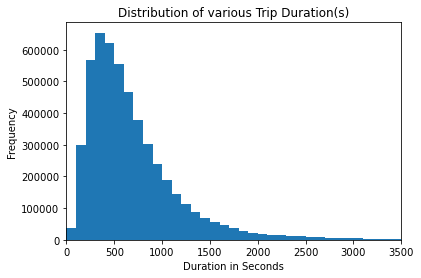

```python
bin_edges = np.arange(0, df_clean['duration_sec'].max() + 100, 100)
plt.hist(data = df_clean, x = 'duration_sec', bins = bin_edges);
plt.title('Distribution of various Trip Duration(s)');
plt.xlabel('Duration in Seconds');
plt.ylabel('Frequency')
plt.xlim(0,3500)
```

This graph depicts a right-skewed distribution with a long right tail. Dispate the fact that the distribution is positive-skew distribution we need to get more details.I intend to apply a logarithmic transformation to x-axis and to use minutes in the duration

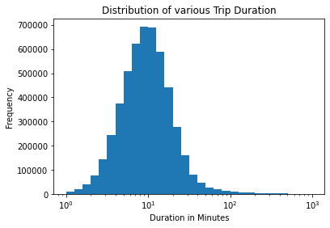

```python
bin_edges = 10**np.arange(0 , 3+0.1 , 0.1)
ticks =  [ 0.1 , 0.3 , 1 , 3, 10, 30, 100, 300]
labels = ['{}'.format(v) for v in ticks]
plt.hist(data = df_clean , x = 'duration_min' , bins = bin_edges);
plt.xticks(ticks,labels);
plt.title('Distribution of various Trip Duration')
plt.xlabel('Duration in Minutes');
plt.ylabel('Frequency')
plt.xscale('log');
```

This is looking better! The figure above shows the tendency of taking a bike for short-time duration trips for above 10 minutes.

#### Understanding the relation betweet users(customers and subcribers) and travel duration.

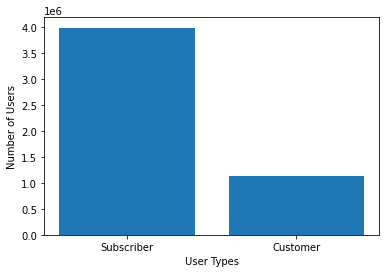

```python
#plotting types of users on the bar chart
# plt.figure(figsize=[8,5])
plt.bar(x = df_clean.user_type.value_counts().keys(), height = df_clean.user_type.value_counts())
plt.xlabel('User Types')
plt.ylabel('Number of Users')
plt.show()
```

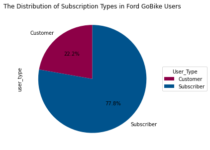

```python
#check user types in percentage
data = df_clean.user_type.value_counts(ascending=True)
fig, ax = plt.subplots(figsize=(8, 5), subplot_kw=dict(aspect="equal"))
data.plot(kind='pie', startangle=90, autopct='%1.1f%%', colors=['#8d0047', '#00538d']);
ax.set_title('The Distribution of Subscription Types in Ford GoBike Users')
ax.legend(title="User_Type",
          loc="center left",
          bbox_to_anchor=(1, 0, 0.5, 1))
plt.show()
```

There are 77.8% users as subscribers

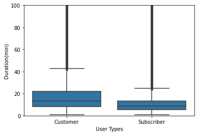

```python
base_color = sb.color_palette()[0]
sb.boxplot(data = df_clean, x = 'user_type', y = 'duration_min', color = base_color)
plt.xlabel('User Types')
plt.ylabel('Duration(min)')
plt.ylim(0, 100)
plt.show()
```

The graph shows that the customers, instead of subscribers causes a greater and more consistent increase in long-trip duration.

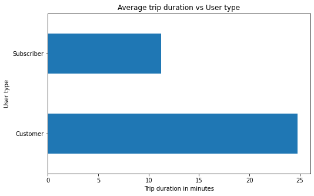

```python
plt.figure(figsize=[8,5])
base_colors= sb.color_palette()[0]
axis = df_clean.groupby('user_type')['duration_min'].mean().plot(kind='barh', color=base_colors)
axis.set_title('Average trip duration vs User type')
axis.set_ylabel('User type')
axis.set_xlabel('Trip duration in minutes')
```

As we can see the average trip duration for subscribers is around 10 minutes and for customers is nearly 25 minutes.

### Riders per month

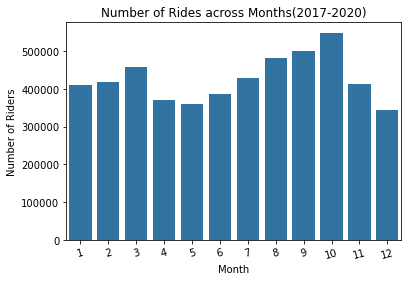

```python
month_name = [1,2,3,4,5,6,7,8,9,10,11,12]
month_index = df_clean.groupby(df_clean['start_time'].dt.month)['start_time'].count().index
month_values = df_clean.groupby(df_clean['start_time'].dt.month)['start_time'].count().values

base_color = sb.color_palette()[0]
sb.barplot(month_index, month_values, order=month_name, color = base_color)
plt.xlabel('Month')
plt.ylabel('Number of Riders')
plt.xticks(rotation=15);
plt.title('Number of Rides across Months(2017-2020)')
```

The bar chart illustrates about total amount of users took a service in the company Bay Area Bike Share. The biggest number was in October.

### Number riders per days

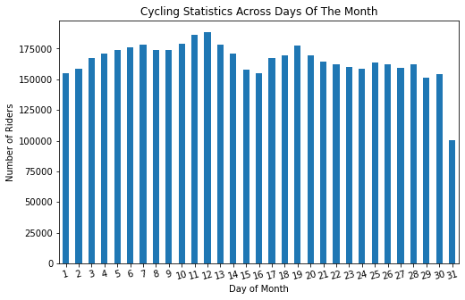

```python
plt.figure(figsize=(8,5))
df_clean.groupby(df_clean['start_time'].dt.day)['start_time'].count().plot(kind='bar');
plt.xticks(rotation=15)
plt.xlabel('Day of Month')
plt.ylabel('Number of Riders')
plt.title('Cycling Statistics Across Days Of The Month')
```

The bar chart depicts the bigger number of renting bikes in the first half of the month

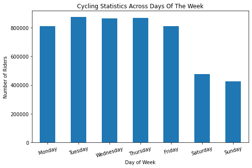

```python
plt.figure(figsize=(8,5))
df_clean.groupby(df_clean['start_time'].dt.dayofweek)['start_time'].count().plot(kind='bar');
week_name = ['Monday', 'Tuesday', 'Wednesday', 'Thursday', 'Friday', 'Saturday', 'Sunday']
plt.xticks([0,1,2,3,4,5,6], week_name, rotation=15);
plt.xlabel('Day of Week')
plt.ylabel('Number of Riders')
plt.title('Cycling Statistics Across Days Of The Week')
```

As it turns out the majority of rides are in the middle of the week

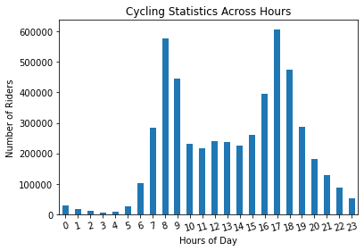

```python
df_clean.groupby(df_clean['start_time'].dt.hour)['start_time'].count().plot(kind='bar');
plt.xticks(rotation=15);
plt.xlabel('Hours of Day')
plt.ylabel('Number of Riders')
plt.title('Cycling Statistics Across Hours')
```

We can see that number of trips is peeking around 7-9 a.m. and 16-18 p.m suggesting commute to work

## Bivariate Exploration

Establish new user groups

```python
df_customer = df_clean[df_clean['user_type'] == 'Customer']
df_subscriber = df_clean[df_clean['user_type'] == 'Subscriber']

#Creating daytime, weekday and month columns
df_clean['month_name']=df_clean['start_time'].dt.strftime('%B')
# df_clean['weekday'] = df_clean['start_time'].dt.day_name()
# df_clean['hour'] = df_clean['start_time'].dt.hour

# # Reorder the weekday values
# df_clean['weekday'] = pd.Categorical(df_clean['weekday'], categories=['Monday','Tuesday','Wednesday','Thursday','Friday','Saturday', 'Sunday'],ordered=True)
```

### User rides across Months

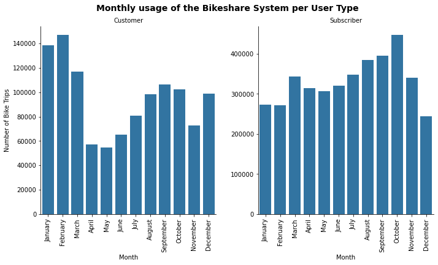

```python
category_order = ['January', 'February', 'March', 'April', 'May', 'June', 'July', 'August',
                 'September', 'October', 'November', 'December']
g = sb.catplot(data=df_clean, x='month_name', col="user_type", kind='count',
               order=category_order, sharex = True, sharey = False, color = base_color)
g.set_axis_labels("Month", "Number of Bike Trips")
g.set_titles("{col_name}")
g.fig.suptitle('Monthly usage of the Bikeshare System per User Type', y=1.03, fontsize=14, fontweight='semibold')
g.set_xticklabels(rotation=90);
```

### User rides across the week days

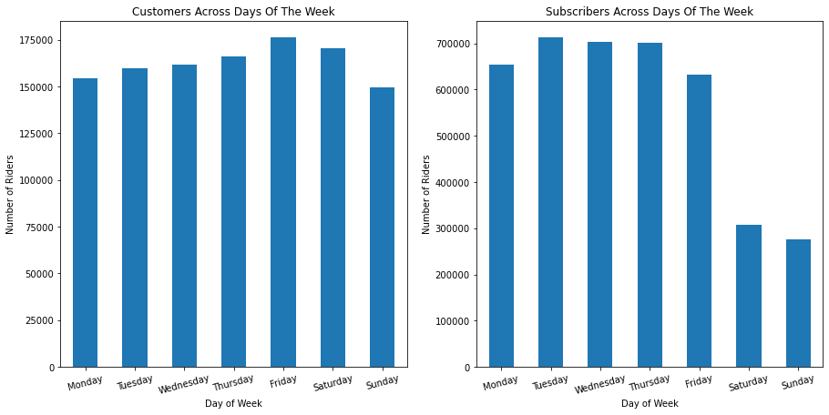

```python
plt.figure(figsize=(15,7))

ax1 = plt.subplot(1, 2, 1)
df_customer.groupby(df_clean['start_time'].dt.dayofweek)['start_time'].count().plot(kind='bar');
plt.xticks([0,1,2,3,4,5,6], week_name, rotation=15);
plt.xlabel('Day of Week')
plt.ylabel('Number of Riders')
plt.title('Customers Across Days Of The Week')


ax1 = plt.subplot(1, 2, 2)
df_subscriber.groupby(df_clean['start_time'].dt.dayofweek)['start_time'].count().plot(kind='bar');
plt.xticks([0,1,2,3,4,5,6], week_name, rotation=15);
plt.xlabel('Day of Week')
plt.ylabel('Number of Riders')
plt.title('Subscribers Across Days Of The Week')
```

### User rides across hours of the day

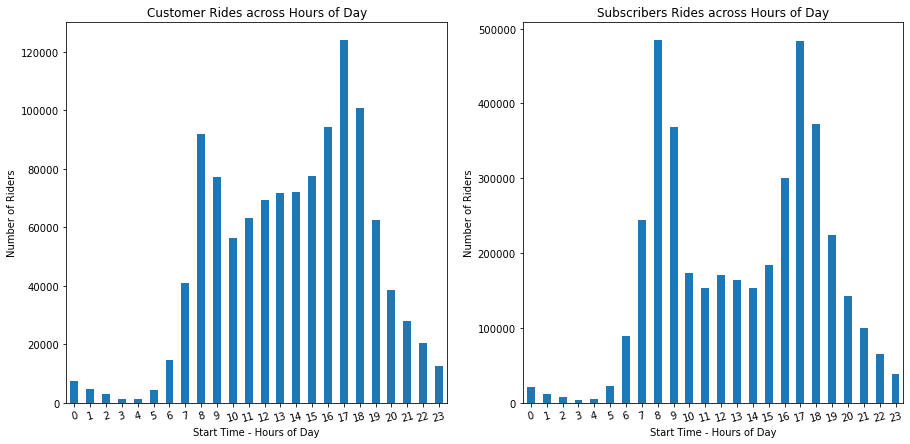

```python
# check the start time
plt.figure(figsize=(15,7))

ax1 = plt.subplot(1, 2, 1)
df_customer.groupby(df_clean['start_time'].dt.hour)['start_time'].count().plot(kind='bar');
plt.xlabel('Start Time - Hours of Day')
plt.xticks(rotation=15)
plt.ylabel('Number of Riders')
plt.title('Customer Rides across Hours of Day')

ax2 = plt.subplot(1, 2, 2)
df_subscriber.groupby(df_clean['start_time'].dt.hour)['start_time'].count().plot(kind='bar');
plt.xticks(rotation=15)
plt.xlabel('Start Time - Hours of Day')
plt.ylabel('Number of Riders')
plt.title('Subscribers Rides across Hours of Day')
```

As we can see the subscribers use a bike-sharing service between 8-9 am and 4-6 pm, while customers using a bike share service seems to increase through the day and peak in the evening

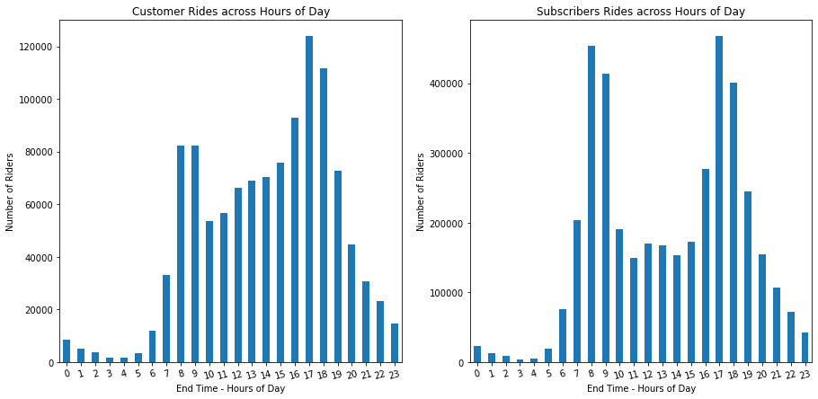

```python
# check the ent time
plt.figure(figsize=(15,7))

ax1 = plt.subplot(1, 2, 1)
df_customer.groupby(df_clean['end_time'].dt.hour)['end_time'].count().plot(kind='bar');
plt.xlabel('End Time - Hours of Day')
plt.xticks(rotation=15)
plt.ylabel('Number of Riders')
plt.title('Customer Rides across Hours of Day')

ax2 = plt.subplot(1, 2, 2)
df_subscriber.groupby(df_clean['end_time'].dt.hour)['end_time'].count().plot(kind='bar');
plt.xticks(rotation=15)
plt.xlabel('End Time - Hours of Day')
plt.ylabel('Number of Riders')
plt.title('Subscribers Rides across Hours of Day')
```

Looks like not many differences with a start time

### Rides by Users across locations

```python
customer_start_loc = df_customer['start_station_id'].value_counts()[:5]
subscriber_start_loc = df_subscriber['start_station_id'].value_counts()[:5]
```

```python
location_label = []
for i in range(5):
    print(df_clean[df_clean['start_station_id'] == (customer_start_loc.index[i])].start_station_name.unique()[0])
```

```
San Francisco Ferry Building (Harry Bridges Plaza)
The Embarcadero at Sansome St
Powell St BART Station (Market St at 4th St)
Market St at 10th St
Berry St at 4th St
```

```python
customer_start_name_loc = ['Harry Bridges Plaza', 'The Embarcadero at Sansome St',
                            'Market St at 4th St', 'Market St at 10th St', 'Berry St at 4th St' ]
```

```python
location_label = []
for i in range(5):
    print(df_clean[df_clean['start_station_id'] == (subscriber_start_loc.index[i])].start_station_name.unique()[0])
```

```
Market St at 10th St
San Francisco Caltrain (Townsend St at 4th St)
San Francisco Caltrain Station 2  (Townsend St at 4th St)
Berry St at 4th St
Montgomery St BART Station (Market St at 2nd St)
```

```python
subcriber_start_name_loc = ['Market St at 10th St', 'Townsend St at 4th St',
                           'Townsend St at 4th St', 'Berry St at 4th St', 'Market St at 2nd St']
```

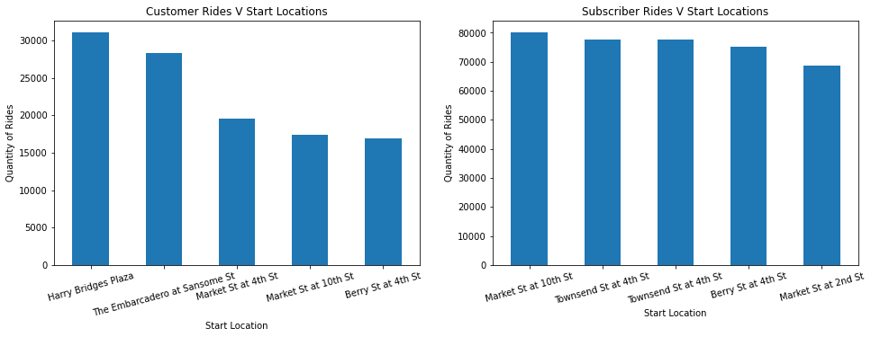

```python
plt.figure(figsize=(16,5))
base_color = sb.color_palette()[0]
ax1 = plt.subplot(1,2,1)
customer_start_loc.plot(kind='bar', color = base_color);
plt.xticks([0,1,2,3,4],customer_start_name_loc,rotation=15);
plt.title('Customer Rides V Start Locations')
plt.xlabel('Start Location')
plt.ylabel('Quantity of Rides')


ax2 = plt.subplot(1,2,2)
subscriber_start_loc.plot(kind='bar', color = base_color);
plt.xticks([0,1,2,3,4], subcriber_start_name_loc, rotation=15);
plt.title('Subscriber Rides V Start Locations')
plt.xlabel('Start Location')
plt.ylabel('Quantity of Rides')
```

```python
customer_end_loc = df_customer['end_station_id'].value_counts()[:5]
subscriber_end_loc = df_subscriber['end_station_id'].value_counts()[:5]
```

```python
location_label = []
for i in range(5):
    print(df_clean[df_clean['end_station_id'] == (customer_end_loc.index[i])].end_station_name.unique()[0])
```

```
The Embarcadero at Sansome St
San Francisco Ferry Building (Harry Bridges Plaza)
San Francisco Caltrain (Townsend St at 4th St)
Powell St BART Station (Market St at 4th St)
Montgomery St BART Station (Market St at 2nd St)
```

```python
customer_end_name_loc = ['The Embarcadero at Sansome St', 'Harry Bridges Plaza', 'Townsend St at 4th St',
                           'Market St at 4th St', 'Market St at 2nd St']
```

```python
location_label = []
for i in range(5):
    print(df_clean[df_clean['end_station_id'] == (subscriber_end_loc.index[i])].end_station_name.unique()[0])
```

```
San Francisco Caltrain Station 2  (Townsend St at 4th St)
San Francisco Caltrain (Townsend St at 4th St)
Montgomery St BART Station (Market St at 2nd St)
San Francisco Ferry Building (Harry Bridges Plaza)
Market St at 10th St
```

```python
subcriber_end_name_loc = ['Townsend St at 4th St', 'San Francisco Caltrain', 'Montgomery St BART Station',
                          'San Francisco Ferry Building', 'Market St at 10th St']
```

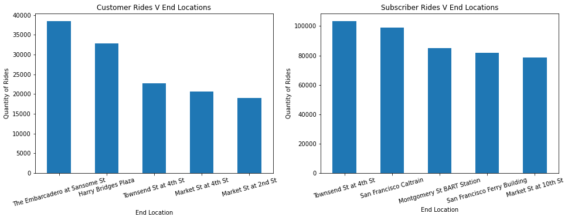

```python
plt.figure(figsize=(16,5))
base_color = sb.color_palette()[0]

ax1 = plt.subplot(1,2,1)
customer_end_loc.plot(kind='bar', color = base_color);
plt.xticks([0,1,2,3,4],customer_end_name_loc,rotation=15);
plt.title('Customer Rides V End Locations')
plt.xlabel('End Location')
plt.ylabel('Quantity of Rides')


ax2 = plt.subplot(1,2,2)
subscriber_end_loc.plot(kind='bar', color = base_color);
plt.xticks([0,1,2,3,4], subcriber_end_name_loc, rotation=15);
plt.title('Subscriber Rides V End Locations')
plt.xlabel('End Location')
plt.ylabel('Quantity of Rides')
```

#### Did you observe any interesting relationships between the other features (not the main feature(s) of interest)?

In comparing the customer type and the most frequent start station of all trips. There was no direct relation between the most frequent station and the customer.

### Multivariate Exploration

The main thing I want to explore in this part is to analyze the distributions between customer and subscriber, based on time frame and distance

```python
df_clean['month_start'] = pd.DatetimeIndex(df_clean['start_time']).month
df_clean['month_start'].value_counts()
```

```
10    548934
9     501179
8     483105
3     459483
7     427781
2     418575
11    413686
1     411233
6     385665
4     370684
5     361273
12    343346
Name: month_start, dtype: int64
```

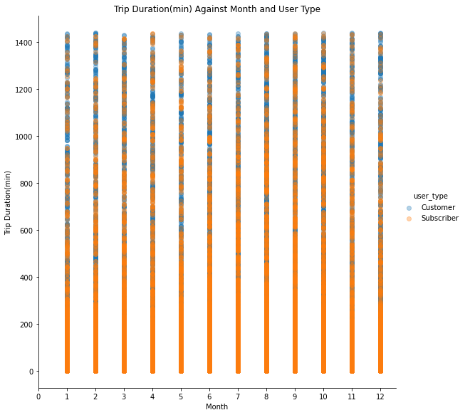

```python
g = sb.FacetGrid(data = df_clean, hue = 'user_type', height = 8)
g.map(plt.scatter, 'month_start','duration_min', alpha = 1/3)
g.add_legend()
plt.xticks([0,1,2,3,4,5,6,7,8,9,10,11,12]);
plt.title('Trip Duration(min) Against Month and User Type')
plt.xlabel('Month')
plt.ylabel('Trip Duration(min)');
plt.show()
```

#### Define

Based the longitude and latitude start and end points I am going to create a column for distance in kilometrs

#### Code

```python
import math
def distance(origin, destination):
    lat1, lon1 = origin
    lat2, lon2 = destination
    radius = 6371 # km
    dlat = math.radians(lat2-lat1)
    dlon = math.radians(lon2-lon1)
    a = math.sin(dlat/2) * math.sin(dlat/2) + math.cos(math.radians(lat1)) \
* math.cos(math.radians(lat2)) * math.sin(dlon/2) * math.sin(dlon/2)
    c = 2 * math.atan2(math.sqrt(a), math.sqrt(1-a))
    d = radius * c
    return d
```

```python
df_clean['distance_km'] = df_clean.apply(lambda i: distance([i['start_station_longitude'],i['start_station_latitude']],
                            [i['end_station_longitude'],i['end_station_latitude']]), axis=1)
```

```python
df_clean.groupby('user_type')['distance_km'].mean()
```

```
user_type
Customer      2.225533
Subscriber    1.530753
Name: distance_km, dtype: float64
```

```python
df_clean['hour'] = df_clean['start_time'].dt.hour
```

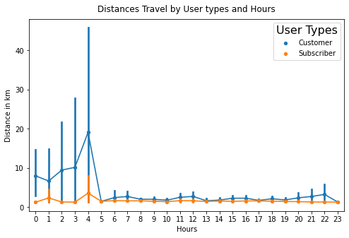

```python
# check distribution between distance and user types, hours
plt.figure(figsize=(8,5))
ax = sb.pointplot(data=df_clean, x ='hour', y = 'distance_km', hue= 'user_type', scale=.6)
plt.title('Distances Travel by User types and Hours', fontsize=12, y=1.015)
plt.xlabel('Hours')
plt.ylabel('Distance in km')
leg = ax.legend()
leg.set_title('User Types', prop={'size':16})
ax = plt.gca()
```

This result might not be clean due to dropping many rows, however this theory can be applicable to investigation

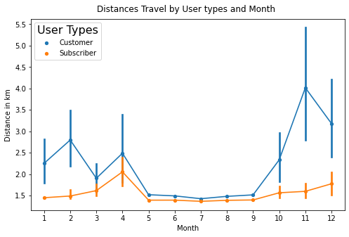

```python
plt.figure(figsize=(8,5))
ax = sb.pointplot(data=df_clean, x ='month_start', y = 'distance_km', hue= 'user_type', scale=.6)
plt.title('Distances Travel by User types and Month ', fontsize=12, y=1.015)
plt.xlabel('Month')
plt.ylabel('Distance in km')
leg = ax.legend()
leg.set_title('User Types', prop={'size':16})
ax = plt.gca()
```

```python
df_clean.to_csv('final_ford_go_bike.csv', index=False, encoding = 'utf-8')
```